# diwali sales

```python
#importing pandas and numpy modules for data cleaning and filtering
import pandas as pd
import numpy as np
```

```python
df=pd.read_csv("Diwali Sales Data.csv",encoding= 'unicode_escape') #readind the csv file
```

```python
df
```

|  | User_ID | Cust_name | Product_ID | Gender | Age Group | Age | Marital_Status | State | Zone | Occupation | Product_Category | Orders | Amount | Status | unnamed1 |
| --- | --- | --- | --- | --- | --- | --- | --- | --- | --- | --- | --- | --- | --- | --- | --- |
| 0 | 1002903 | Sanskriti | P00125942 | F | 26-35 | 28 | 0 | Maharashtra | Western | Healthcare | Auto | 1 | 23952.0 | NaN | NaN |
| 1 | 1000732 | Kartik | P00110942 | F | 26-35 | 35 | 1 | Andhra Pradesh | Southern | Govt | Auto | 3 | 23934.0 | NaN | NaN |
| 2 | 1001990 | Bindu | P00118542 | F | 26-35 | 35 | 1 | Uttar Pradesh | Central | Automobile | Auto | 3 | 23924.0 | NaN | NaN |
| 3 | 1001425 | Sudevi | P00237842 | M | 0-17 | 16 | 0 | Karnataka | Southern | Construction | Auto | 2 | 23912.0 | NaN | NaN |
| 4 | 1000588 | Joni | P00057942 | M | 26-35 | 28 | 1 | Gujarat | Western | Food Processing | Auto | 2 | 23877.0 | NaN | NaN |
| ... | ... | ... | ... | ... | ... | ... | ... | ... | ... | ... | ... | ... | ... | ... | ... |
| 11246 | 1000695 | Manning | P00296942 | M | 18-25 | 19 | 1 | Maharashtra | Western | Chemical | Office | 4 | 370.0 | NaN | NaN |
| 11247 | 1004089 | Reichenbach | P00171342 | M | 26-35 | 33 | 0 | Haryana | Northern | Healthcare | Veterinary | 3 | 367.0 | NaN | NaN |
| 11248 | 1001209 | Oshin | P00201342 | F | 36-45 | 40 | 0 | Madhya Pradesh | Central | Textile | Office | 4 | 213.0 | NaN | NaN |
| 11249 | 1004023 | Noonan | P00059442 | M | 36-45 | 37 | 0 | Karnataka | Southern | Agriculture | Office | 3 | 206.0 | NaN | NaN |
| 11250 | 1002744 | Brumley | P00281742 | F | 18-25 | 19 | 0 | Maharashtra | Western | Healthcare | Office | 3 | 188.0 | NaN | NaN |

11251 rows × 15 columns

```python
df.head() # to show first fiive rows
```

|  | User_ID | Cust_name | Product_ID | Gender | Age Group | Age | Marital_Status | State | Zone | Occupation | Product_Category | Orders | Amount | Status | unnamed1 |
| --- | --- | --- | --- | --- | --- | --- | --- | --- | --- | --- | --- | --- | --- | --- | --- |
| 0 | 1002903 | Sanskriti | P00125942 | F | 26-35 | 28 | 0 | Maharashtra | Western | Healthcare | Auto | 1 | 23952.0 | NaN | NaN |
| 1 | 1000732 | Kartik | P00110942 | F | 26-35 | 35 | 1 | Andhra Pradesh | Southern | Govt | Auto | 3 | 23934.0 | NaN | NaN |
| 2 | 1001990 | Bindu | P00118542 | F | 26-35 | 35 | 1 | Uttar Pradesh | Central | Automobile | Auto | 3 | 23924.0 | NaN | NaN |
| 3 | 1001425 | Sudevi | P00237842 | M | 0-17 | 16 | 0 | Karnataka | Southern | Construction | Auto | 2 | 23912.0 | NaN | NaN |
| 4 | 1000588 | Joni | P00057942 | M | 26-35 | 28 | 1 | Gujarat | Western | Food Processing | Auto | 2 | 23877.0 | NaN | NaN |

```python
df.info() # to show the datatype of each column
```

```
<class 'pandas.core.frame.DataFrame'>
RangeIndex: 11251 entries, 0 to 11250
Data columns (total 15 columns):
 #   Column            Non-Null Count  Dtype
---  ------            --------------  -----
 0   User_ID           11251 non-null  int64
 1   Cust_name         11251 non-null  object
 2   Product_ID        11251 non-null  object
 3   Gender            11251 non-null  object
 4   Age Group         11251 non-null  object
 5   Age               11251 non-null  int64
 6   Marital_Status    11251 non-null  int64
 7   State             11251 non-null  object
 8   Zone              11251 non-null  object
 9   Occupation        11251 non-null  object
 10  Product_Category  11251 non-null  object
 11  Orders            11251 non-null  int64
 12  Amount            11239 non-null  float64
 13  Status            0 non-null      float64
 14  unnamed1          0 non-null      float64
dtypes: float64(3), int64(4), object(8)
memory usage: 1.3+ MB
```

```python
#drop unrelated/blank columns
df.drop(['Status', 'unnamed1'], axis=1, inplace=True)
```

```python
# to check null values
df.isna().sum()
```

```
User_ID              0
Cust_name            0
Product_ID           0
Gender               0
Age Group            0
Age                  0
Marital_Status       0
State                0
Zone                 0
Occupation           0
Product_Category     0
Orders               0
Amount              12
dtype: int64
```

```python
#since amount only has 12 null values will drop that values
df.dropna(inplace=True)
```

```python
#changing data type of amount from float to int
df['Amount']=df['Amount'].astype(int)
```

```python
#check the column names
df.columns
```

```
Index(['User_ID', 'Cust_name', 'Product_ID', 'Gender', 'Age Group', 'Age',
       'Marital_Status', 'State', 'Zone', 'Occupation', 'Product_Category',
       'Orders', 'Amount'],
      dtype='object')
```

```python
df.rename(columns={'Cust_name':'Customer_name'}) #renaming a column
```

|  | User_ID | Customer_name | Product_ID | Gender | Age Group | Age | Marital_Status | State | Zone | Occupation | Product_Category | Orders | Amount |
| --- | --- | --- | --- | --- | --- | --- | --- | --- | --- | --- | --- | --- | --- |
| 0 | 1002903 | Sanskriti | P00125942 | F | 26-35 | 28 | 0 | Maharashtra | Western | Healthcare | Auto | 1 | 23952 |
| 1 | 1000732 | Kartik | P00110942 | F | 26-35 | 35 | 1 | Andhra Pradesh | Southern | Govt | Auto | 3 | 23934 |
| 2 | 1001990 | Bindu | P00118542 | F | 26-35 | 35 | 1 | Uttar Pradesh | Central | Automobile | Auto | 3 | 23924 |
| 3 | 1001425 | Sudevi | P00237842 | M | 0-17 | 16 | 0 | Karnataka | Southern | Construction | Auto | 2 | 23912 |
| 4 | 1000588 | Joni | P00057942 | M | 26-35 | 28 | 1 | Gujarat | Western | Food Processing | Auto | 2 | 23877 |
| ... | ... | ... | ... | ... | ... | ... | ... | ... | ... | ... | ... | ... | ... |
| 11246 | 1000695 | Manning | P00296942 | M | 18-25 | 19 | 1 | Maharashtra | Western | Chemical | Office | 4 | 370 |
| 11247 | 1004089 | Reichenbach | P00171342 | M | 26-35 | 33 | 0 | Haryana | Northern | Healthcare | Veterinary | 3 | 367 |
| 11248 | 1001209 | Oshin | P00201342 | F | 36-45 | 40 | 0 | Madhya Pradesh | Central | Textile | Office | 4 | 213 |
| 11249 | 1004023 | Noonan | P00059442 | M | 36-45 | 37 | 0 | Karnataka | Southern | Agriculture | Office | 3 | 206 |
| 11250 | 1002744 | Brumley | P00281742 | F | 18-25 | 19 | 0 | Maharashtra | Western | Healthcare | Office | 3 | 188 |

11239 rows × 13 columns

```python
# describe() method returns description of the data in the DataFrame (i.e. count, mean, std, etc)
df.describe()
```

|  | User_ID | Age | Marital_Status | Orders | Amount |
| --- | --- | --- | --- | --- | --- |
| count | 1.123900e+04 | 11239.000000 | 11239.000000 | 11239.000000 | 11239.000000 |
| mean | 1.003004e+06 | 35.410357 | 0.420055 | 2.489634 | 9453.610553 |
| std | 1.716039e+03 | 12.753866 | 0.493589 | 1.114967 | 5222.355168 |
| min | 1.000001e+06 | 12.000000 | 0.000000 | 1.000000 | 188.000000 |
| 25% | 1.001492e+06 | 27.000000 | 0.000000 | 2.000000 | 5443.000000 |
| 50% | 1.003064e+06 | 33.000000 | 0.000000 | 2.000000 | 8109.000000 |
| 75% | 1.004426e+06 | 43.000000 | 1.000000 | 3.000000 | 12675.000000 |
| max | 1.006040e+06 | 92.000000 | 1.000000 | 4.000000 | 23952.000000 |

```python
# use describe() for specific columns
df[['Age', 'Orders', 'Amount']].describe()
```

|  | Age | Orders | Amount |
| --- | --- | --- | --- |
| count | 11239.000000 | 11239.000000 | 11239.000000 |
| mean | 35.410357 | 2.489634 | 9453.610553 |
| std | 12.753866 | 1.114967 | 5222.355168 |
| min | 12.000000 | 1.000000 | 188.000000 |
| 25% | 27.000000 | 2.000000 | 5443.000000 |
| 50% | 33.000000 | 2.000000 | 8109.000000 |
| 75% | 43.000000 | 3.000000 | 12675.000000 |
| max | 92.000000 | 4.000000 | 23952.000000 |

# Exploratory Data Analysis

# univariate analysis for categorial values

```python
import  matplotlib.pyplot as plt
import seaborn as sns
```

```python
#seperation of categorical and continous values
cat = list(df.columns[df.dtypes=='object'])
con = list(df.columns[df.dtypes!='object'])
```

```
printing countplots for categorical values
```

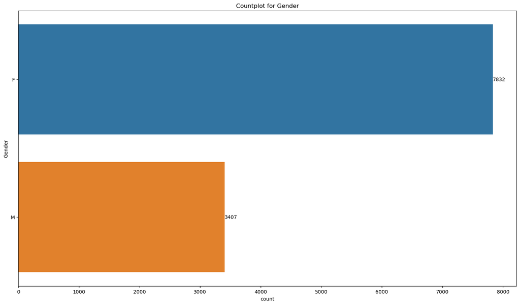

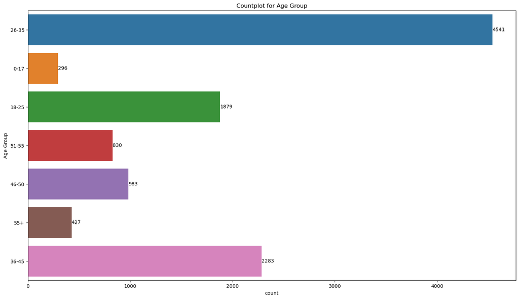

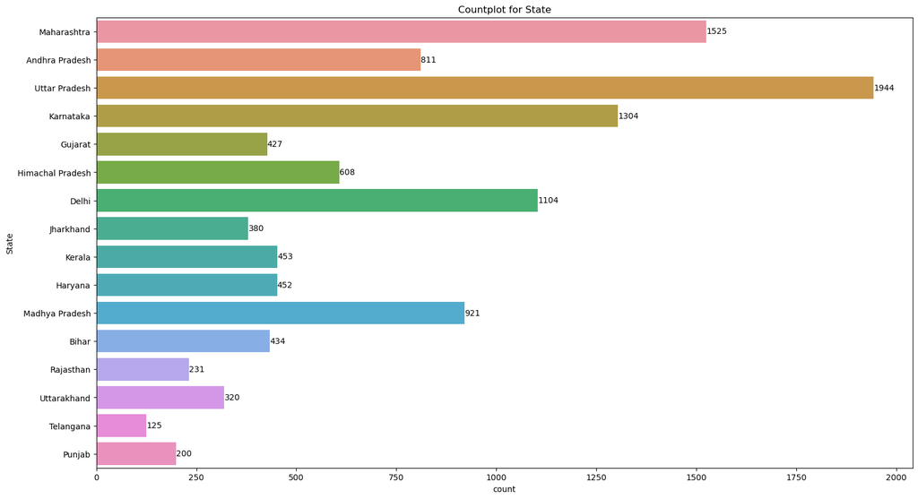

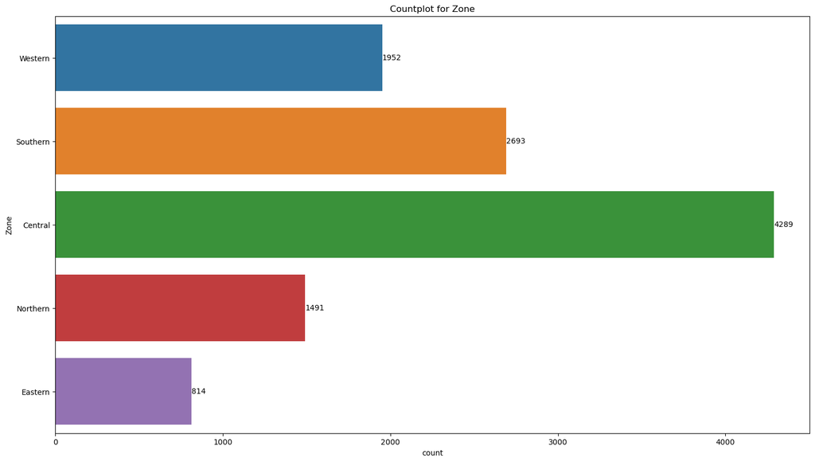

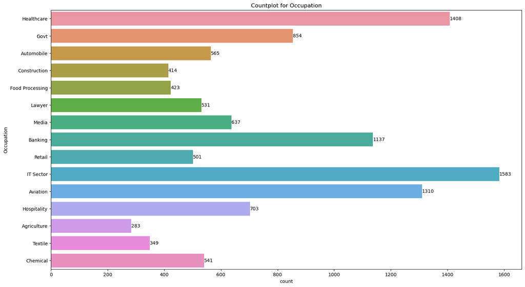

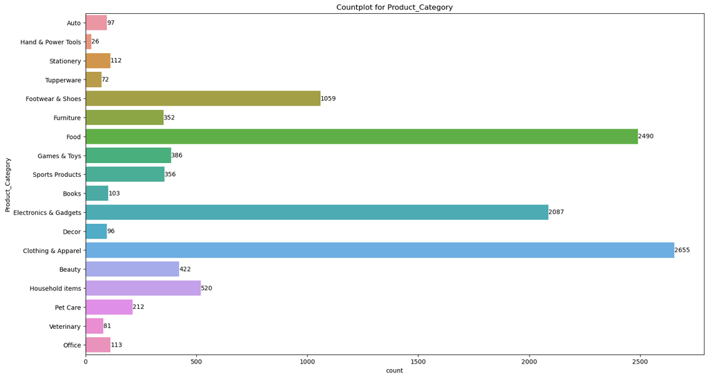

```python
#plotting categorial plots
print("printing countplots for categorical values")

categorical=df[["Gender","Age Group","State","Zone","Occupation","Product_Category"]]

cat=list(categorical.columns)

for j in categorical:
    plt.figure(figsize=(18,10))
    ax=sns.countplot(data=categorical,y=j)
    for bars in ax.containers:
        ax.bar_label(bars)
    plt.title(f'Countplot for {j}')
    plt.show()
```

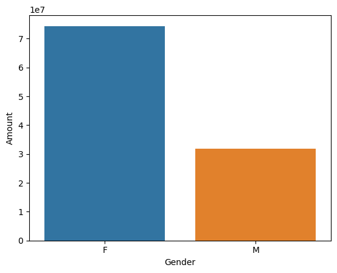

```python
# plotting a bar chart for gender vs total amount
sales_gen=df.groupby(['Gender'],as_index=False)["Amount"].sum().sort_values(by='Amount',ascending=False)
sns.barplot(data=sales_gen,x='Gender',y='Amount')
```

From above graphs we can see that most of the buyers are females and even the purchasing power of females are greater than men

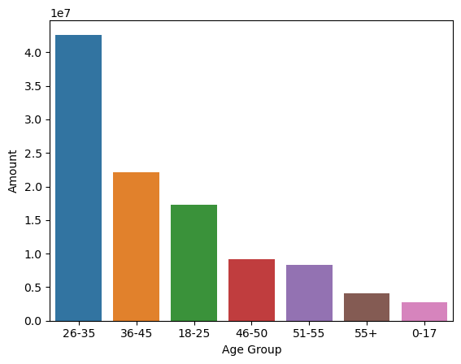

```python
# Total Amount vs Age Group
sales_age = df.groupby(['Age Group'], as_index=False)['Amount'].sum().sort_values(by='Amount', ascending=False)

sns.barplot(x = 'Age Group',y= 'Amount' ,data = sales_age)
```

From above graphs we can see that most of the buyers are of age group between 26-35 yrs female

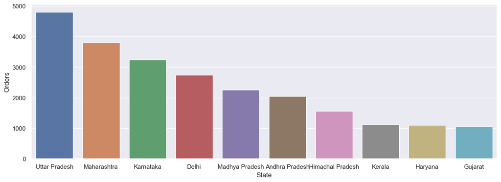

```python
# total number of orders from top 10 states
sales_state=df.groupby(["State"],as_index=False)['Orders'].sum().sort_values('Orders',ascending=False).head(10)
sns.set(rc={'figure.figsize':(15,5)})
sns.barplot(data=sales_state,x='State',y='Orders')
```

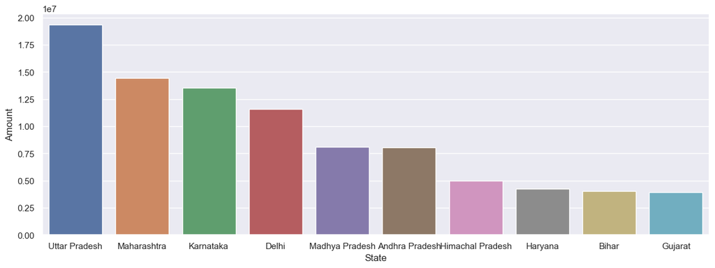

```python
# total amount/sales from top 10 states

sales_state = df.groupby(['State'], as_index=False)['Amount'].sum().sort_values(by='Amount', ascending=False).head(10)

sns.set(rc={'figure.figsize':(15,5)})
sns.barplot(data = sales_state, x = 'State',y= 'Amount')
```

From above graphs we can see that most of the orders & total sales/amount are from Uttar Pradesh, Maharashtra and Karnataka respectively

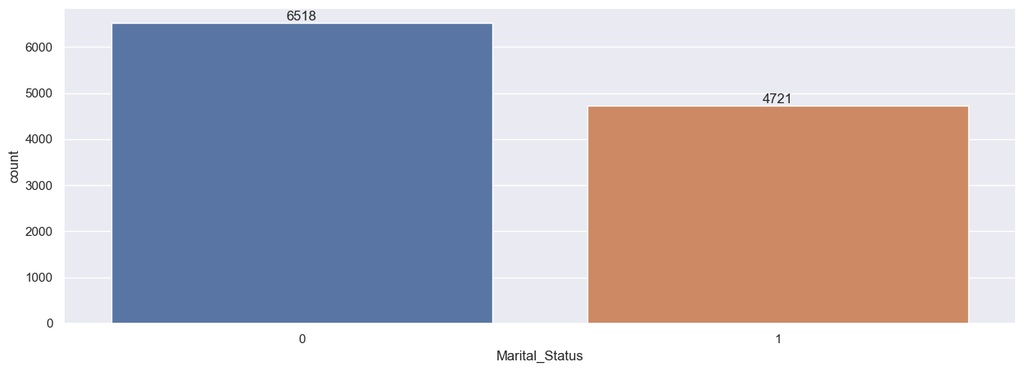

```python
ax = sns.countplot(data = df, x = 'Marital_Status')

sns.set(rc={'figure.figsize':(7,5)})
for bars in ax.containers:
    ax.bar_label(bars)
```

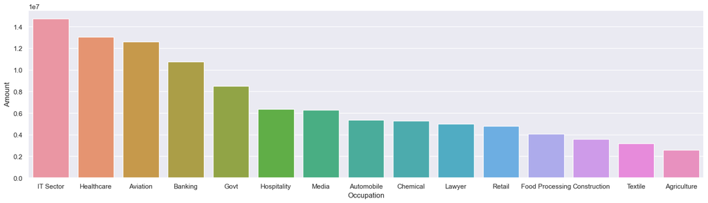

```python
sales_state = df.groupby(['Occupation'], as_index=False)['Amount'].sum().sort_values(by='Amount', ascending=False)

sns.set(rc={'figure.figsize':(20,5)})
sns.barplot(data = sales_state, x = 'Occupation',y= 'Amount')
```

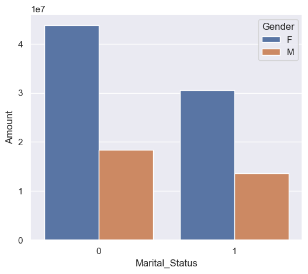

```python
sales_state = df.groupby(['Marital_Status', 'Gender'], as_index=False)['Amount'].sum().sort_values(by='Amount', ascending=False)

sns.set(rc={'figure.figsize':(6,5)})
sns.barplot(data = sales_state, x = 'Marital_Status',y= 'Amount', hue='Gender')
```

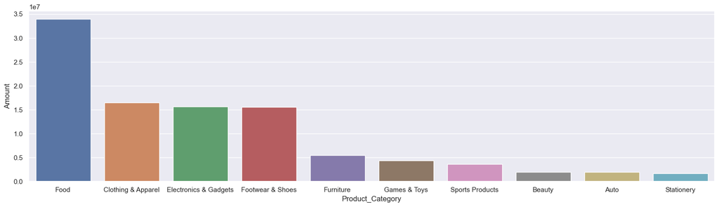

```python
sales_state = df.groupby(['Product_Category'], as_index=False)['Amount'].sum().sort_values(by='Amount', ascending=False).head(10)

sns.set(rc={'figure.figsize':(20,5)})
sns.barplot(data = sales_state, x = 'Product_Category',y= 'Amount')
```

From above graphs we can see that most of the sold products are from Food, Clothing and Electronics category

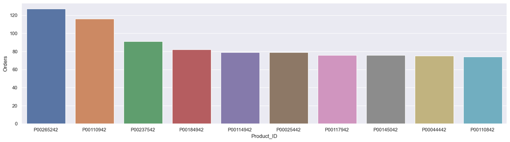

```python
# top 10 most sold products
sales_state = df.groupby(['Product_ID'], as_index=False)['Orders'].sum().sort_values(by='Orders', ascending=False).head(10)

sns.set(rc={'figure.figsize':(20,5)})
sns.barplot(data = sales_state, x = 'Product_ID',y= 'Orders')
```

# univariate analysis for numerical values

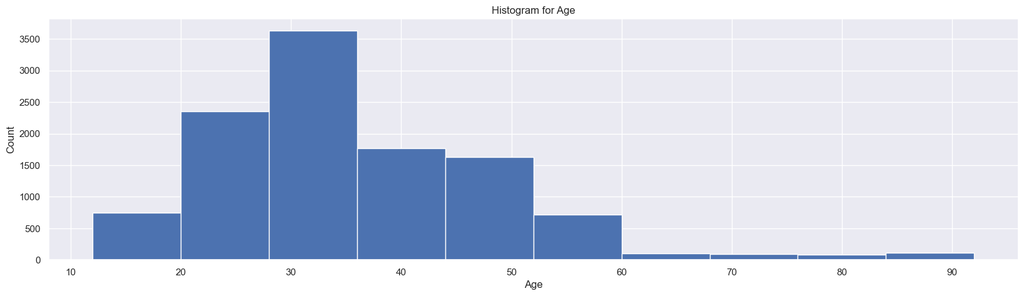

```python
plt.hist(df['Age'])
plt.xlabel("Age")
plt.ylabel("Count")
plt.title("Histogram for Age")
plt.show()
```

```
C:\Users\Dattaram Malkar\anaconda3\Lib\site-packages\seaborn\_oldcore.py:1119: FutureWarning: use_inf_as_na option is deprecated and will be removed in a future version. Convert inf values to NaN before operating instead.
  with pd.option_context('mode.use_inf_as_na', True):
```

[figure not shown]

```python
sns.histplot(data = df , x= df["Amount"] , kde= True, hue = df["Gender"])
plt.xlabel("Orders")
plt.ylabel("Count")
plt.title("Histogram for Orders")
plt.show()
```

# Bivariate Analysis

CATEGORICAL VS NUMERICAL

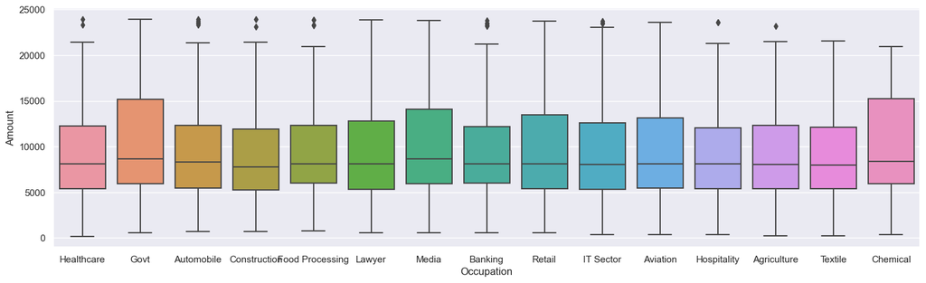

```python
plt.figure(figsize=(18,5))
sns.boxplot(x='Occupation',y='Amount',data=df)
```

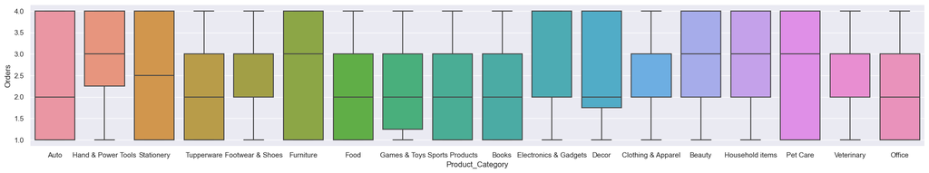

```python
plt.figure(figsize=(25,4))
sns.boxplot(x='Product_Category',y='Orders',data=df)
```

```python
cat
```

```
['Gender', 'Age Group', 'State', 'Zone', 'Occupation', 'Product_Category']
```

categorical vs categorical

```python
c=pd.crosstab(df['Occupation'],df['Gender'])
c
```

| Gender Occupation | F | M |
| --- | --- | --- |
| Agriculture | 203 | 80 |
| Automobile | 391 | 174 |
| Aviation | 932 | 378 |
| Banking | 823 | 314 |
| Chemical | 378 | 163 |
| Construction | 300 | 114 |
| Food Processing | 295 | 128 |
| Govt | 605 | 249 |
| Healthcare | 968 | 440 |
| Hospitality | 468 | 235 |
| IT Sector | 1071 | 512 |
| Lawyer | 364 | 167 |
| Media | 428 | 209 |
| Retail | 370 | 131 |
| Textile | 236 | 113 |

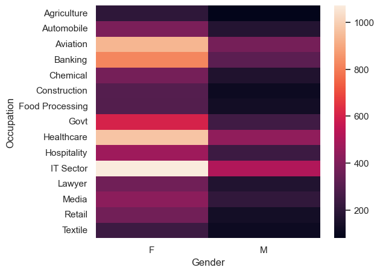

```python
plt.figure(figsize=(6,5))
sns.heatmap(c)
```

Females From IT sectors are most buyers

```python
df['Zone']
```

```
0         Western
1        Southern
2         Central
3        Southern
4         Western
           ...
11246     Western
11247    Northern
11248     Central
11249    Southern
11250     Western
Name: Zone, Length: 11239, dtype: object
```

```python
c2=pd.crosstab(df['State'],df['Zone'])
c2
```

| Zone State | Central | Eastern | Northern | Southern | Western |
| --- | --- | --- | --- | --- | --- |
| Andhra Pradesh | 0 | 0 | 0 | 811 | 0 |
| Bihar | 0 | 434 | 0 | 0 | 0 |
| Delhi | 1104 | 0 | 0 | 0 | 0 |
| Gujarat | 0 | 0 | 0 | 0 | 427 |
| Haryana | 0 | 0 | 452 | 0 | 0 |
| Himachal Pradesh | 0 | 0 | 608 | 0 | 0 |
| Jharkhand | 0 | 380 | 0 | 0 | 0 |
| Karnataka | 0 | 0 | 0 | 1304 | 0 |
| Kerala | 0 | 0 | 0 | 453 | 0 |
| Madhya Pradesh | 921 | 0 | 0 | 0 | 0 |
| Maharashtra | 0 | 0 | 0 | 0 | 1525 |
| Punjab | 0 | 0 | 200 | 0 | 0 |
| Rajasthan | 0 | 0 | 231 | 0 | 0 |
| Telangana | 0 | 0 | 0 | 125 | 0 |
| Uttar Pradesh | 1944 | 0 | 0 | 0 | 0 |
| Uttarakhand | 320 | 0 | 0 | 0 | 0 |

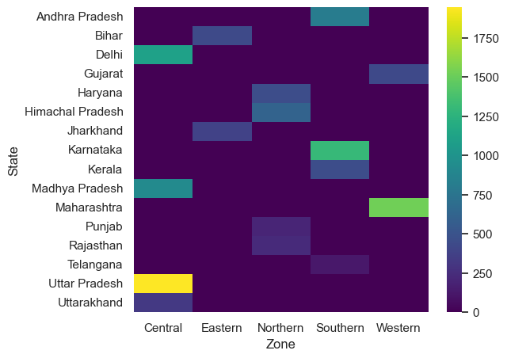

```python
plt.figure(figsize=(6,5))
sns.heatmap(c2,cmap='viridis')
```

Customers are more form central uttarpradesh

# Multivariate analysis

Multivariate analysis involves examining the relationships between multiple variables simultaneously. It helps in understanding complex interactions and dependencies

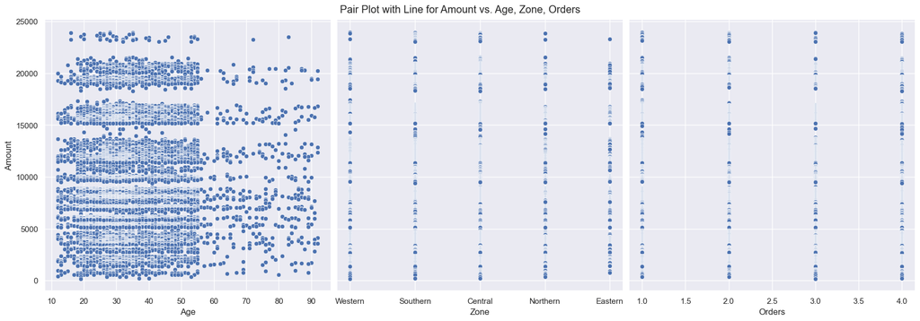

```python
sns.pairplot(df, x_vars=['Age', 'Zone', 'Orders'], y_vars='Amount',height=6)
plt.suptitle('Pair Plot with Line for Amount vs. Age, Zone, Orders', y=1.02)
plt.show()
```

## Conclusion

univariate . biravariate and Multivariate analysis was sucessfully performed